# Web Scraping Project: Visualize and Analyze Starbucks Coffee Store Amenities

Jhonasttan Regalado

11/12/2016

## Problem: Multiple clicks are required to list Starbucks Coffee store amenities

### [Starbucks Store Locator page](https://www.starbucks.com/store-locator?map=39.635307,-101.337891,5z)

## Goal: Visualize the Starbucks Coffee Store locations and their amenities

### Scope:

- Scrapy for web scraping stores and their amenities via Starbucks Coffee Store Locator website
- R for numerical / visual EDA
- CARTO for visual EDA
- MCA (Multiple Correspondence Analysis) for analyzing commonalities between the amenities
- Map layer for Shiny Citibike Analysis app

### [Visual EDA TIME!!!](https://jhonasttan.carto.com/viz/69f64b70-a6c8-11e6-8d32-0e233c30368f/public_map)

### The Process:

#### Scrapy the magic sauce:

[figure not shown]

#### Processed data provides store geospatial information and associated amenities

- Regex (regular expressions) for feature engineering amenities data - used as filter criteria in CARTO map layers
- HTML wrapper for store location - CARTO renders fields in HTML format out of the box
- Duplicate rows!! Not an issue for CARTO which treats geospatial locations as unique

[figure not shown]

#### View of the CARTO ready data after processing in Scrapy and R is complete:

|  | StoreId | Name | PhoneNumber | Longitude | Latitude | Address | Amenities | AmenitiesCarto | StoreNameUrl | Url | CL | WA | WF | CD | DR | LB | GO | FZ | XO | LU | RW | PS | CS | MX | VS | NB | SQ | EM | BA | … |
| --- | --- | --- | --- | --- | --- | --- | --- | --- | --- | --- | --- | --- | --- | --- | --- | --- | --- | --- | --- | --- | --- | --- | --- | --- | --- | --- | --- | --- | --- | --- |
| 1 | 11040 | Church Street &amp;amp; Murray | 212-513-1451 | -74.009126 | 40.71378 | "120 Church Street","New York, NY 10007" | {u'LB': u'LaBoulange', u'XO': u'Mobile Order and Pay', u'WA': u'Oven-warmed Food', u'CD': u'Mobile Payment', u'LU': u'Lunch', u'GO': u'Google Wi-Fi', u'DR': u'Digital Rewards', u'MX': u'Music Experien… | &lt;ul&gt;LaBoulange&lt;li&gt;Mobile Order and Pay&lt;li&gt;Oven-warmed Food&lt;li&gt;Mobile Payment&lt;li&gt;Lunch&lt;li&gt;Google Wi-Fi&lt;li&gt;Digital Rewards&lt;li&gt;Music Experience&lt;/ul&gt; | &lt;a href="https://www.starbucks.com/store-locator/store/11040/church-street-murray-120-church-street-new-york-ny-100072402-us"&gt;Church Street &amp;amp; Murray&lt;/a&gt; | https://www.starbucks.com/store-locator/store/11040/church-street-murray-120-church-street-new-york-ny-100072402-us | 0 | 1 | 0 | 1 | 1 | 1 | 1 | 0 | 1 | 1 | 0 | 0 | 0 | 1 | 0 | 0 | 0 | 0 | 0 | … |
| 2 | 8692 | Chambers and West Broadway | 212-791-6368 | -74.009036 | 40.715536 | "125 Chambers Street","New York, NY 10007" | {u'LB': u'LaBoulange', u'XO': u'Mobile Order and Pay', u'WA': u'Oven-warmed Food', u'CD': u'Mobile Payment', u'LU': u'Lunch', u'GO': u'Google Wi-Fi', u'DR': u'Digital Rewards', u'MX': u'Music Experien… | &lt;ul&gt;LaBoulange&lt;li&gt;Mobile Order and Pay&lt;li&gt;Oven-warmed Food&lt;li&gt;Mobile Payment&lt;li&gt;Lunch&lt;li&gt;Google Wi-Fi&lt;li&gt;Digital Rewards&lt;li&gt;Music Experience&lt;/ul&gt; | &lt;a href="https://www.starbucks.com/store-locator/store/8692/chambers-and-west-broadway-125-chambers-street-new-york-ny-100071331-us"&gt;Chambers and West Broadway&lt;/a&gt; | https://www.starbucks.com/store-locator/store/8692/chambers-and-west-broadway-125-chambers-street-new-york-ny-100071331-us | 0 | 1 | 0 | 1 | 1 | 1 | 1 | 0 | 1 | 1 | 0 | 0 | 0 | 1 | 0 | 0 | 0 | 0 | 0 | … |
| 3 | 13537 | Broadway at Barclay Str | 212-619-1529 | -74.008192 | 40.712208 | "233 Broadway","New York, NY 10279" | {u'LB': u'LaBoulange', u'XO': u'Mobile Order and Pay', u'WA': u'Oven-warmed Food', u'CD': u'Mobile Payment', u'LU': u'Lunch', u'GO': u'Google Wi-Fi', u'DR': u'Digital Rewards', u'MX': u'Music Experien… | &lt;ul&gt;LaBoulange&lt;li&gt;Mobile Order and Pay&lt;li&gt;Oven-warmed Food&lt;li&gt;Mobile Payment&lt;li&gt;Lunch&lt;li&gt;Google Wi-Fi&lt;li&gt;Digital Rewards&lt;li&gt;Music Experience&lt;/ul&gt; | &lt;a href="https://www.starbucks.com/store-locator/store/13537/broadway-at-barclay-str-233-broadway-new-york-ny-102790001-us"&gt;Broadway at Barclay Str&lt;/a&gt; | https://www.starbucks.com/store-locator/store/13537/broadway-at-barclay-str-233-broadway-new-york-ny-102790001-us | 0 | 1 | 0 | 1 | 1 | 1 | 1 | 0 | 1 | 1 | 0 | 0 | 0 | 1 | 0 | 0 | 0 | 0 | 0 | … |
| 4 | 16209 | 195 Broadway | 212 3851104 | -74.010283 | 40.710924 | "195 Broadway","New York, NY 10007" | {u'WF': u'Wireless Hotspot', u'LB': u'LaBoulange', u'XO': u'Mobile Order and Pay', u'WA': u'Oven-warmed Food', u'LU': u'Lunch', u'CD': u'Mobile Payment', u'VS': u'Verismo', u'DR': u'Digital Rewards', … | &lt;ul&gt;Wireless Hotspot&lt;li&gt;LaBoulange&lt;li&gt;Mobile Order and Pay&lt;li&gt;Oven-warmed Food&lt;li&gt;Lunch&lt;li&gt;Mobile Payment&lt;li&gt;Verismo&lt;li&gt;Digital Rewards&lt;li&gt;Music E… | &lt;a href="https://www.starbucks.com/store-locator/store/16209/195-broadway-195-broadway-new-york-ny-100073100-us"&gt;195 Broadway&lt;/a&gt; | https://www.starbucks.com/store-locator/store/16209/195-broadway-195-broadway-new-york-ny-100073100-us | 0 | 1 | 1 | 1 | 1 | 1 | 0 | 0 | 1 | 1 | 0 | 0 | 0 | 1 | 1 | 0 | 0 | 0 | 0 | … |
| 5 | 18526 | Broadway &amp;amp; Reade | 212 406 5310 | -74.005933 | 40.714855 | "291 Broadway","New York, NY 10007" | {u'WF': u'Wireless Hotspot', u'LB': u'LaBoulange', u'XO': u'Mobile Order and Pay', u'WA': u'Oven-warmed Food', u'CD': u'Mobile Payment', u'LU': u'Lunch', u'DR': u'Digital Rewards', u'MX': u'Music Expe… | &lt;ul&gt;Wireless Hotspot&lt;li&gt;LaBoulange&lt;li&gt;Mobile Order and Pay&lt;li&gt;Oven-warmed Food&lt;li&gt;Mobile Payment&lt;li&gt;Lunch&lt;li&gt;Digital Rewards&lt;li&gt;Music Experience&lt;/ul&… | &lt;a href="https://www.starbucks.com/store-locator/store/18526/broadway-reade-291-broadway-new-york-ny-100071814-us"&gt;Broadway &amp;amp; Reade&lt;/a&gt; | https://www.starbucks.com/store-locator/store/18526/broadway-reade-291-broadway-new-york-ny-100071814-us | 0 | 1 | 1 | 1 | 1 | 1 | 0 | 0 | 1 | 1 | 0 | 0 | 0 | 1 | 0 | 0 | 0 | 0 | 0 | … |
| 6 | 1014357 | 222 Broadway | 6466476873 | -74.008646 | 40.710798 | "222 Broadway","New York, NY 10007" | {u'PS': u'Playbook Store System', u'RW': u'My Starbucks Rewards', u'LB': u'LaBoulange', u'XO': u'Mobile Order and Pay', u'WA': u'Oven-warmed Food', u'LU': u'Lunch', u'GO': u'Google Wi-Fi', u'DR': u'Di… | &lt;ul&gt;Playbook Store System&lt;li&gt;My Starbucks Rewards&lt;li&gt;LaBoulange&lt;li&gt;Mobile Order and Pay&lt;li&gt;Oven-warmed Food&lt;li&gt;Lunch&lt;li&gt;Google Wi-Fi&lt;li&gt;Digital Rewards&… | &lt;a href="https://www.starbucks.com/store-locator/store/1014357/222-broadway-222-broadway-new-york-ny-10007-us"&gt;222 Broadway&lt;/a&gt; | https://www.starbucks.com/store-locator/store/1014357/222-broadway-222-broadway-new-york-ny-10007-us | 0 | 1 | 0 | 0 | 1 | 1 | 1 | 0 | 1 | 1 | 1 | 1 | 0 | 1 | 0 | 0 | 0 | 0 | 0 | … |
| 7 | 1015738 | Brookfield Place 2 | 6466185392 | -74.015437 | 40.71417 | "250 Vesey Street","203","New York, NY 10281" | {u'WF': u'Wireless Hotspot', u'RW': u'My Starbucks Rewards', u'LB': u'LaBoulange', u'XO': u'Mobile Order and Pay', u'WA': u'Oven-warmed Food', u'CL': u'Starbucks Reserve-Clover Brewed', u'PS': u'Playb… | &lt;ul&gt;Wireless Hotspot&lt;li&gt;My Starbucks Rewards&lt;li&gt;LaBoulange&lt;li&gt;Mobile Order and Pay&lt;li&gt;Oven-warmed Food&lt;li&gt;Starbucks Reserve-Clover Brewed&lt;li&gt;Playbook Store Sy… | &lt;a href="https://www.starbucks.com/store-locator/store/1015738/brookfield-place-2-250-vesey-street-new-york-ny-10281-us"&gt;Brookfield Place 2&lt;/a&gt; | https://www.starbucks.com/store-locator/store/1015738/brookfield-place-2-250-vesey-street-new-york-ny-10281-us | 1 | 1 | 1 | 1 | 1 | 1 | 1 | 1 | 1 | 1 | 1 | 1 | 1 | 0 | 0 | 0 | 0 | 0 | 0 | … |
| 8 | 12020 | Park Row at Beekman St | 212-608-8073 | -74.006667 | 40.711644 | "38 Park Row","#4","New York, NY 10038" | {u'LB': u'LaBoulange', u'XO': u'Mobile Order and Pay', u'WA': u'Oven-warmed Food', u'CD': u'Mobile Payment', u'LU': u'Lunch', u'GO': u'Google Wi-Fi', u'DR': u'Digital Rewards', u'MX': u'Music Experien… | &lt;ul&gt;LaBoulange&lt;li&gt;Mobile Order and Pay&lt;li&gt;Oven-warmed Food&lt;li&gt;Mobile Payment&lt;li&gt;Lunch&lt;li&gt;Google Wi-Fi&lt;li&gt;Digital Rewards&lt;li&gt;Music Experience&lt;/ul&gt; | &lt;a href="https://www.starbucks.com/store-locator/store/12020/park-row-at-beekman-st-38-park-row-new-york-ny-100381551-us"&gt;Park Row at Beekman St&lt;/a&gt; | https://www.starbucks.com/store-locator/store/12020/park-row-at-beekman-st-38-park-row-new-york-ny-100381551-us | 0 | 1 | 0 | 1 | 1 | 1 | 1 | 0 | 1 | 1 | 0 | 0 | 0 | 1 | 0 | 0 | 0 | 0 | 0 | … |
| 9 | 10655 | Nassau &amp;amp; Fulton | 212-962-0439 | -74.007931 | 40.710171 | "130 Fulton Street","New York, NY 10038" | {u'LB': u'LaBoulange', u'XO': u'Mobile Order and Pay', u'WA': u'Oven-warmed Food', u'LU': u'Lunch', u'CD': u'Mobile Payment', u'VS': u'Verismo', u'GO': u'Google Wi-Fi', u'DR': u'Digital Rewards', u'MX… | &lt;ul&gt;LaBoulange&lt;li&gt;Mobile Order and Pay&lt;li&gt;Oven-warmed Food&lt;li&gt;Lunch&lt;li&gt;Mobile Payment&lt;li&gt;Verismo&lt;li&gt;Google Wi-Fi&lt;li&gt;Digital Rewards&lt;li&gt;Music Exper… | &lt;a href="https://www.starbucks.com/store-locator/store/10655/nassau-fulton-130-fulton-street-new-york-ny-100382504-us"&gt;Nassau &amp;amp; Fulton&lt;/a&gt; | https://www.starbucks.com/store-locator/store/10655/nassau-fulton-130-fulton-street-new-york-ny-100382504-us | 0 | 1 | 0 | 1 | 1 | 1 | 1 | 0 | 1 | 1 | 0 | 0 | 0 | 1 | 1 | 0 | 0 | 0 | 0 | … |
| 10 | 14988 | 165 Broadway - 1 Liberty | 212 6086481 | -74.010424 | 40.709527 | "165 Broadway","New York, NY 10006" | {u'WF': u'Wireless Hotspot', u'LB': u'LaBoulange', u'XO': u'Mobile Order and Pay', u'WA': u'Oven-warmed Food', u'CD': u'Mobile Payment', u'LU': u'Lunch', u'DR': u'Digital Rewards', u'MX': u'Music Expe… | &lt;ul&gt;Wireless Hotspot&lt;li&gt;LaBoulange&lt;li&gt;Mobile Order and Pay&lt;li&gt;Oven-warmed Food&lt;li&gt;Mobile Payment&lt;li&gt;Lunch&lt;li&gt;Digital Rewards&lt;li&gt;Music Experience&lt;/ul&… | &lt;a href="https://www.starbucks.com/store-locator/store/14988/165-broadway-1-liberty-165-broadway-liberty-plaza-new-york-ny-100061404-u"&gt;165 Broadway - 1 Liberty&lt;/a&gt; | https://www.starbucks.com/store-locator/store/14988/165-broadway-1-liberty-165-broadway-liberty-plaza-new-york-ny-100061404-u | 0 | 1 | 1 | 1 | 1 | 1 | 0 | 0 | 1 | 1 | 0 | 0 | 0 | 1 | 0 | 0 | 0 | 0 | 0 | … |

[output cut: 219 more lines]

#### List of Amenities:

[interactive chart not shown]

#### Five most common amenities:

- LB: LaBoulange
- WA: Oven-warmed Food
- LU: Lunch
- DR: Digital Rewards
- XO: Mobile Order and Pay

#### Five least common amenities:

- DT: Drive-Through
- EM: Starbucks Evenings
- WT: tbd - Walk-T
- FZ: Fizzio Handcrafted Sodas
- hrs24: Open 24 hours per day

### MCA (Multiple Correspondence Analysis)

#### As with PCA and Correspondence Analysis, MCA allows us to analyze the systematic patterns of variations with categorical data.

#### List the eigen values

```
##         eigenvalue percentage of variance
## dim 1  0.229307542             22.9307542
## dim 2  0.108699691             10.8699691
## dim 3  0.077774909              7.7774909
## dim 4  0.067799432              6.7799432
## dim 5  0.057700086              5.7700086
## dim 6  0.052447829              5.2447829
## dim 7  0.050270614              5.0270614
## dim 8  0.047859791              4.7859791
## dim 9  0.044506750              4.4506750
## dim 10 0.043505613              4.3505613
## dim 11 0.037468709              3.7468709
## dim 12 0.034816182              3.4816182
## dim 13 0.031310764              3.1310764
## dim 14 0.025410279              2.5410279
## dim 15 0.022428156              2.2428156
## dim 16 0.020807183              2.0807183
## dim 17 0.016384901              1.6384901
## dim 18 0.011369265              1.1369265
## dim 19 0.007996684              0.7996684
## dim 20 0.005336062              0.5336062
## dim 21 0.004379128              0.4379128
## dim 22 0.002420429              0.2420429
##        cumulative percentage of variance
## dim 1                           22.93075
## dim 2                           33.80072
## dim 3                           41.57821
## dim 4                           48.35816
## dim 5                           54.12817
## dim 6                           59.37295
## dim 7                           64.40001
## dim 8                           69.18599
## dim 9                           73.63666
## dim 10                          77.98723
## dim 11                          81.73410
## dim 12                          85.21571
## dim 13                          88.34679
## dim 14                          90.88782
## dim 15                          93.13063
## dim 16                          95.21135
## dim 17                          96.84984
## dim 18                          97.98677
## dim 19                          98.78644
## dim 20                          99.32004
## dim 21                          99.75796
## dim 22                         100.00000
```

#### View the relationships

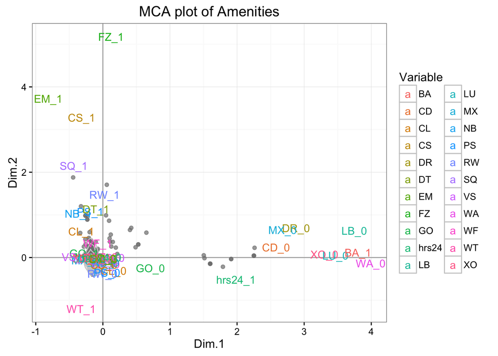

#### Five most common amenities:

- LB: LaBoulange
- WA: Oven-warmed Food
- LU: Lunch
- DR: Digital Rewards
- XO: Mobile Order and Pay

##### MCA results shows amenities CD (Mobile Payment) and MX (Music Experience) within the cluster having the five most common amenities.

#### Five least common amenities:

- DT: Drive-Through
- EM: Starbucks Evenings
- WT: tbd - Walk-T
- FZ: Fizzio Handcrafted Sodas
- hrs24: Open 24 hours per day

### Follow ups:

1. Highlight the Most / Least common amenities when the user hovers over a store location in CARTO
2. Create a Map Layer for Shiny Citibike Analysis app, allowing users to locate Starbucks Coffee stores based on amenities and proximity

[LinkedIn: Jhonasttan Regalado](https://www.linkedin.com/in/jhonasttanregalado)